# Part II - Loan Data Explanation

## by Yusuff O. Olaniyi

## Investigation Overview

> In this investigation, I want to look at the features that contribute to having good credit score and the effect of same on Loan amount. The main focus was on the original loan amount, credit score, borrower's stated monthly income, Employment Status and Occupation.

## Dataset Overview

> The dataset contains 111207 loans with 21 features (including LoanOriginalAmount, CreditScore, BorrowerAPR, StatedMonthlyIncome, EmploymentStatus and many others)

### Distribution of loans listed year, Quarter and month wise

> January has the highest number of loans listed as expected from starting of new year, whereas april sees the least number of loans listed. Despite this, the fourth quarter recorded the highest number of laons. There is an upward trend in loans listed with each passing year from 2009 to 2013 while there is a reduction in the number of loans in 2014

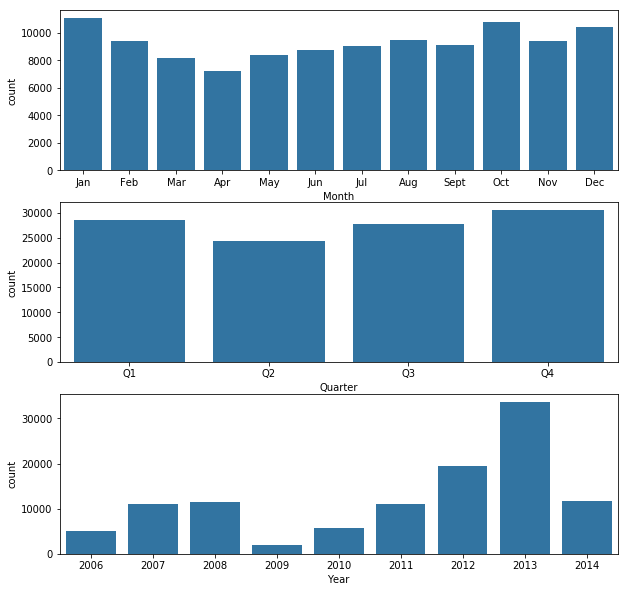

### Distribution of Borrower APR

> The distribution of APR looks multimodal. A small peak centered at 0.1, a large peak centered at 0.2. There is also a small peak centered 0.3. Additionally, there is a very shape peak between 0.35 and 0.36. Only very few loans have APR greater than 0.43.

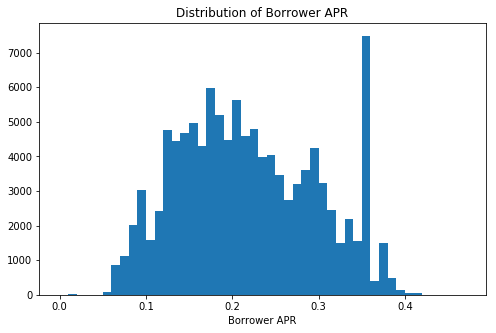

### Distribution of DebtToIncomeRatio

> Distribution has unimodal peak around 0.2 with unusual peak around 0.25 which indicates most people prefer 1:4 ratio of debt to Income which is a good thing.

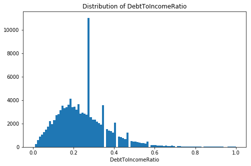

### Borrower APR vs. Loan Amount

> As the loan amount increases, the range of APR decreases. Meaning that, the borrower APR decreases with increase of loan amount

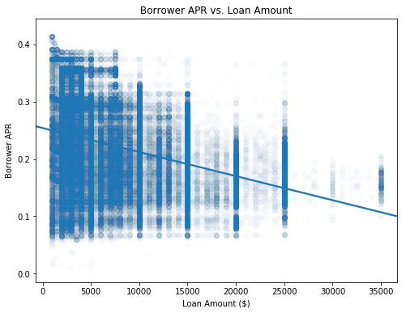

### Borrower APR vs. Credit Score

> The borrower APR decreases with the increasingly better score. Borrowers with the best Credit Score have the lowest APR. It means that the Credit Score has a strong effect on borrower APR.

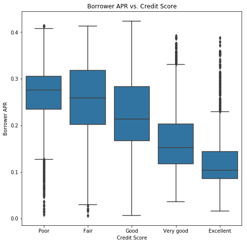

### Loan Amount vs. Cedit Score

> Borrowers with Poor credit score have most loans below 5000 and the distribution grows taller as the cedit score improves. Hence, as the credit score gets better, the loan amount also improves

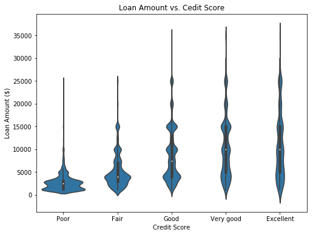

### Effect of Credit Score on Relationship between APR and Loan Amount

> The loan amount increases with better score. The borrower APR decreases with better rating. Interestingly, the relationship between borrower APR and loan amount turns started as 0 for Poor score, then to negative for Fair, Good and Very good while positve for Excellent.

> Generally, the higher the APR the lower the loan amount, except for people with credit score of 800 and above where the loan amount increases with the APR.

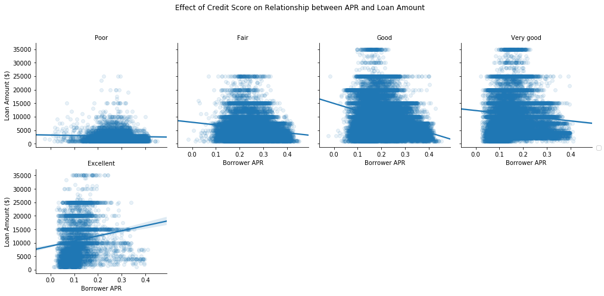

### DebtToIncomeRatio by Employment Status and Credit Score

> Generally, the average debt-to-income ratio rises between Poor credit score and Good and then drops between Good and Excellent

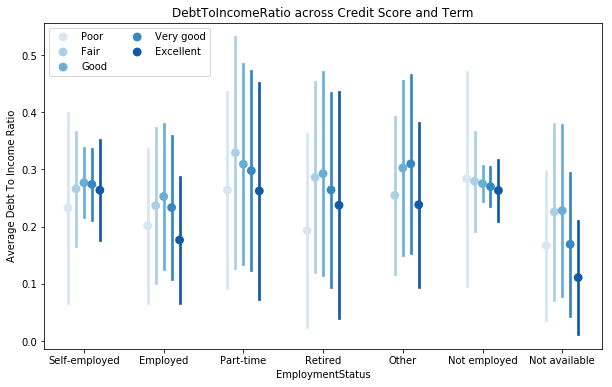

### StatedMonthlyIncome and LoanOriginalAmount by Employment Status and Credit Score

> It seems loan amount is more dependent on credit score than employment status as unemployed borrowers with excellent credit score have an average loan of 8000.

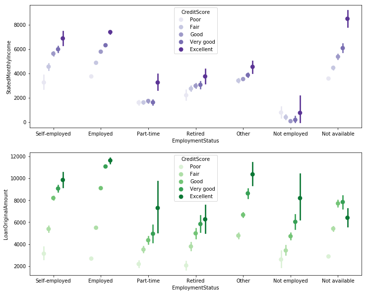